# Introduction to OceanSDM

2026-04-13

Predicting the dynamic, three-dimensional distributions of marine species is challenging given most SDM tools currently can only predict static 2D habitats (but see an example of voluModel package,Owens & Rahbek, 2023). Here, we present a novel package ‘OceanSDM’ to fill this gap. This package includes 18 user-friendly functions helping researchers to complete tasks from initial data extraction to final publication-quality figure creation. It can be split into three major sections: (1) Prepare species and environmental data, (2) Build 2D SDMs for each temporal bin and generate related figures, and (3) Estimate suitable/preferred depth and map the 3D habitat for each temporal bin. Here I illustrate the utility of this package with a pelagic shark (whale shark). For the temporal bin, I used quarterly bins (four bins).

Here are the packages you need.

```r
library(OceanSDM) # This package
library(lubridate) # For editing date
library(ENMTML) # For constructing 2D SDMs
library(raster) # For dealing with raster files
library(terra) # For preparing raster files
library(sdm) # For estimating species response curves
library(ncdf4) # For dealing with .nc files
library(ggplot2) # For figure generation
library(dplyr) # To dealing with dataframe files
```

# 1. Prepare species and environmental data

## 1.1 Download species data from GBIF and OBIS using ob_data()

The Global Biodiversity Information Faculty (GBIF) and Ocean Biodiversity Information System (OBIS) are the two major sources of species occurrences at the global scale. The function ob_data() helps users automatically download the geo-referenced occurrences of either a single or many species. Here I demonstrated with an example of smaller temporal and spatial ranges than the real case in the paper to save the running time for creating this vignette.

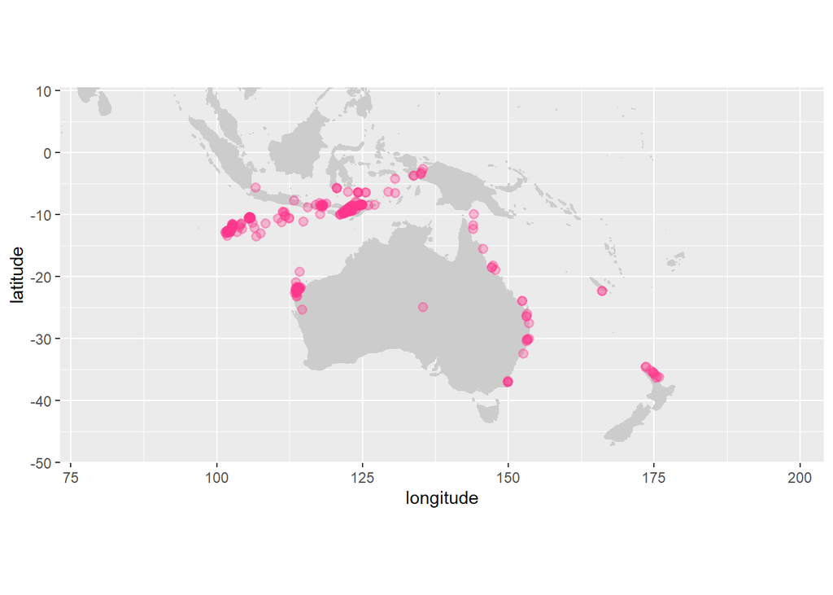

```r
 ws_occ<-ob_data(
 key<-'Rhincodon typus' ,# It can be a vector of the Latin names of all focal species
 sp_geometry <- "POLYGON ((90 -41, 90 0, 180 0, 180 -41, 90 -41))", # Replace this to "POLYGON ((90 -41, 90 40, 180 40, 180 -41, 90 -41))" to simulate my real case study!!!
 start_date<-"2020-01-01", # Replace this to "2015-01-01" to simulate my real case study!!!
 end_date<-"2024-12-30",
 event_date<-'2020-01-01,2024-12-30') # Replace this to '2015-01-01,2024-12-30' to simulate my real case study!!!
Retrieved 67 records of approximately 67 (100%)


```

```r
# # save the occurrences
# write.csv(ws_occ$sp_occ,"F:/whaleshark_sdm/occ/R_typus.csv",row.names = F)
```

## 1.2 Download .nc files of marine environmental predictors using env_download()

The Copernicus Marine Service (CMS) offers dynamic, three-dimensional environmental data that can be extracted with the function env_download(). But please note you must first install the copernicusmarine toolbox (and configure its running environment with conda or other softwares, see details at https://help.marine.copernicus.eu/en/articles/7970514-copernicus-marine-toolbox-installation) on which this function was built. Here I only showed a case of extracting sea surface temperature at smaller temporal and geographic ranges than the real case I used in the paper.

```r
## Set up the path of the cms downloading tool and output directory
path_cms<-"C:/shark/miniconda/envs/copernicusmarine/Scripts/copernicusmarine.exe"
out_dir <- "F:/whaleshark_sdm/cmems"
```

### 1.2.1 Extract surface layer of marine environmental predictors

```r
productId <- "cmems_mod_glo_phy-mnstd_my_0.25deg_P1M-m"
variable <- " --variable thetao_mean"
date_min <- ymd(20200101) # start_date, it should be ymd(20150101) in the paper
date_max <- ymd(20241201) # end_date
lon<-c(90,180)
lat<-c(-41,0) # latitudinal range, it should be c(-41,40) in the paper
## sea surface temperature
depth <- list(0.51, 2) # depth_min, depth_max
out_name <- paste("IndoWPac_temp_1m_y2020_y2024.nc", sep="") # it should be paste("IndoWPac_temp_1m_y2015_y2024.nc", sep="") in the paper
env_download(path_cms,out_dir,productId,variable,
              date_min,date_max,lon,lat,depth,out_name)
```

```
#> [1] "C:/shark/miniconda/envs/copernicusmarine/Scripts/copernicusmarine.exe subset -i cmems_mod_glo_phy-mnstd_my_0.25deg_P1M-m -x 90 -X 180 -y -41 -Y 0 -t 2020-01-01 -T 2024-12-01 -z 0.51 -Z 2  --variable thetao_mean -o F:/whaleshark_sdm/cmems -f IndoWPac_temp_1m_y2020_y2024.nc --force-download"
#> [1] 0
```

```r
## sea surface height
# variable <- " --variable zos_mean"
# out_name <- paste("IndoWPac_slh_1m_y2015_y2024.nc", sep="")
# env_download(path_cms,out_dir,productId,variable,
#             date_min,date_max,lon,lat,depth,out_name)
## mixed layer depth
# variable <- " --variable mlotst_mean"
# out_name <- paste("IndoWPac_mlt_1m_y2015_y2024.nc", sep="")
# env_download(path_cms,out_dir,productId,variable,
#             date_min,date_max,lon,lat,depth,out_name)
## salinity
# variable <- " --variable so_mean"
# out_name <- paste("IndoWPac_so_1m_y2015_y2024.nc", sep="")
# env_download(path_cms,out_dir,productId,variable,
#             date_min,date_max,lon,lat,depth,out_name)
```

### 1.2.2 Extract multiple depth layers of ocean temperature

```r
# variable <- " --variable thetao_mean"

# depth <- list(0.50, 200) # depth_min, depth_max
# out_name <- paste("IndoWPac_temp_200m_y2015_y2024.nc", sep="")
# env_download(path_cms,out_dir,productId,variable,
#             date_min,date_max,lon,lat,depth,out_name)
# depth <- list(200, 400) # depth_min, depth_max
# out_name <- paste("IndoWPac_temp_200_400m_y2015_y2024.nc", sep="")
# env_download(path_cms,out_dir,productId,variable,
#             date_min,date_max,lon,lat,depth,out_name)
# depth <- list(400, 1050) # depth_min, depth_max
# out_name <- paste("IndoWPac_temp_400_1050m_y2015_y2024.nc", sep="")
#env_download(path_cms,out_dir,productId,variable,
#             date_min,date_max,lon,lat,depth,out_name)
# depth <- list(1050, 1946) # depth_min, depth_max
# out_name <- paste("IndoWPac_temp_1050_1946m_y2015_y2024.nc", sep="")
#env_download(path_cms,out_dir,productId,variable,
#             date_min,date_max,lon,lat,depth,out_name)
```

### 1.2.3 Extract sea surface data for npp and o2 from another CMS dataset

```r
# out_dir <- "F:/cmems"
# productId <- "cmems_mod_glo_bgc_my_0.25deg_P1M-m"
# date_min <- ymd(20150101) # start_date
# date_max <- ymd(20241201) # end_date
# lon<-c(90,180)
# lat<-c(-41,40)
# depth <- list(0.51, 2) # depth_min, depth_max
# variable <- " --variable nppv"
# out_name <- paste("IndoWPac_npp_1m_y2015_y2024.nc", sep="")
# env_download(path_cms,out_dir,productId,variable,
#             date_min,date_max,lon,lat,depth,out_name)

# variable <- " --variable o2"
# out_name <- paste("IndoWPac_o2_1m_y2015_y2024.nc", sep="")
# env_download(path_cms,out_dir,productId,variable,
#             date_min,date_max,lon,lat,depth,out_name)
```

For extracting predictor datasets of future projections, please check https://esgf-node.llnl.gov/search/cmip6/ There is also an R package for downloading CMIP6 data: https://github.com/marine-ecologist/CMIP6/blob/main/CMIP6_projections.R

### 1.2.4 Prepare temporally-binned predictors using env_bin()

To predict the dynamic distributions of marine species across the 2D space, all predictors should be aggregated into mean values within the specific temporal bins.

```r
gc() # clear the R environment
```

```
#>            used  (Mb) gc trigger   (Mb)  max used   (Mb)
#> Ncells 10026804 535.5   17383204  928.4  17383204  928.4
#> Vcells 93338809 712.2  170043173 1297.4 198981968 1518.2
```

```r
## sea surface temperature
env_bin(sp_trait="pelagic",
        env_path="F:/whaleshark_sdm/cmems/IndoWPac_temp_1m_y2020_y2024.nc",
# in the paper, I used "F:/whaleshark_sdm/cmems/IndoWPac_temp_1m_y2015_y2024.nc"
       out_dir="F:/whaleshark_sdm/bin2",
# in the paper, I used "F:/whaleshark_sdm/bin"
        var_name="thetao_mean",
        lon_min=90,
       lon_max=180,
        lat_min=-41,
        lat_max=0, # in the paper, I used 40
       date_min=ymd(20200101), # in the paper, I used ymd(20150101)
        date_max = ymd(20241201),
        temporal_bin="quarterly")



## sea surface height
# env_bin(sp_trait="pelagic",
#        env_path="F:/cmems/IndoWPac_slh_1m_y2015_y2024.nc",
#        out_dir="F:/whaleshark_sdm/bin",
#        var_name="zos_mean",
#        lon_min=90,
#        lon_max=180,
#        lat_min=-41,
#        lat_max=40,
#        date_min=ymd(20150101),
#        date_max = ymd(20241201),
#        lag_days= 50,
#        temporal_bin="quarterly")
## mixed layer depth
# env_bin(sp_trait="pelagic",
#        env_path="F:/cmems/IndoWPac_mlt_1m_y2015_y2024.nc",
#        out_dir="F:/whaleshark_sdm/bin",
#        var_name="mlotst_mean",
#        lon_min=90,
#        lon_max=180,
#        lat_min=-41,
#        lat_max=40,
#        date_min=ymd(20150101),
#        date_max = ymd(20241201),
#        lag_days= 50,
#        temporal_bin="quarterly")
## sea surface salinity
# env_bin(sp_trait="pelagic",
#        env_path="F:/cmems/IndoWPac_so_1m_y2015_y2024.nc",
#        out_dir="F:/whaleshark_sdm/bin",
#        var_name="so_mean",
#        lon_min=90,
#        lon_max=180,
#        lat_min=-41,
#        lat_max=40,
#        date_min=ymd(20150101),
#        date_max = ymd(20241201),
#        lag_days= 50,
#        temporal_bin="quarterly")
## sea surface NPP
# env_bin(sp_trait="pelagic",
#        env_path="F:/cmems/IndoWPac_npp_1m_y2015_y2024.nc",
#        out_dir="F:/whaleshark_sdm/bin",
#        var_name="nppv",
#        lon_min=90,
#        lon_max=180,
#        lat_min=-41,
#        lat_max=40,
#        date_min=ymd(20150101),
#        date_max = ymd(20241201),
#        lag_days= 50,
#        temporal_bin="quarterly")
## sea surface dissolved oxygen
# env_bin(sp_trait="pelagic",
#        env_path="F:/cmems/IndoWPac_o2_1m_y2015_y2024.nc",
#        out_dir="F:/whaleshark_sdm/bin",
#        var_name="o2",
#        lon_min=90,
#        lon_max=180,
#        lat_min=-41,
#        lat_max=40,
#        date_min=ymd(20150101),
#        date_max = ymd(20241201),
#        lag_days= 50,
#        temporal_bin="quarterly")
```

### 1.2.5 Download the depth dataset

The Bio-ORACLE provides statistics of ocean depths (mean, maximum, etc.). Here I did not run the code while creating this vignette, but you can run it after removing hash tags.

```r
# install.packages("devtools")
# devtools::install_github("bio-oracle/biooracler")
# library(biooracler)
# library(terra)
# list<-list_layers("Ocean depth")
# dataset_id <- list$dataset_id[158]
# latitude <- c(-41, 40)
# longitude <- c(90, 179.975)
# constraints <- list(latitude, longitude)
# names(constraints) <- c("latitude", "longitude")
# variables <- "bathymetry_mean"
# depth <- download_layers(dataset_id, variables, constraints)
# depth<-abs(depth) # convert values to positive.
# so<-terra::rast("F:/whaleshark_sdm/bin/Q4_so_mean.asc")
# depth_resampled <- resample(depth, so, method = "bilinear")
# writeRaster(raster(depth_resampled),"F:/whaleshark_sdm/bin/depth_mean.asc",
#     format="ascii",NAflag=-9999,overwrite=TRUE)
```

### 1.2.6 Plot environmental predictors (optional)

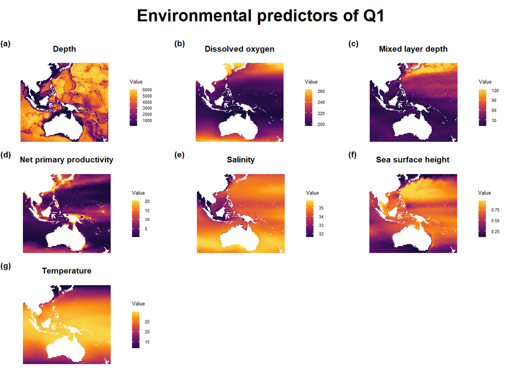

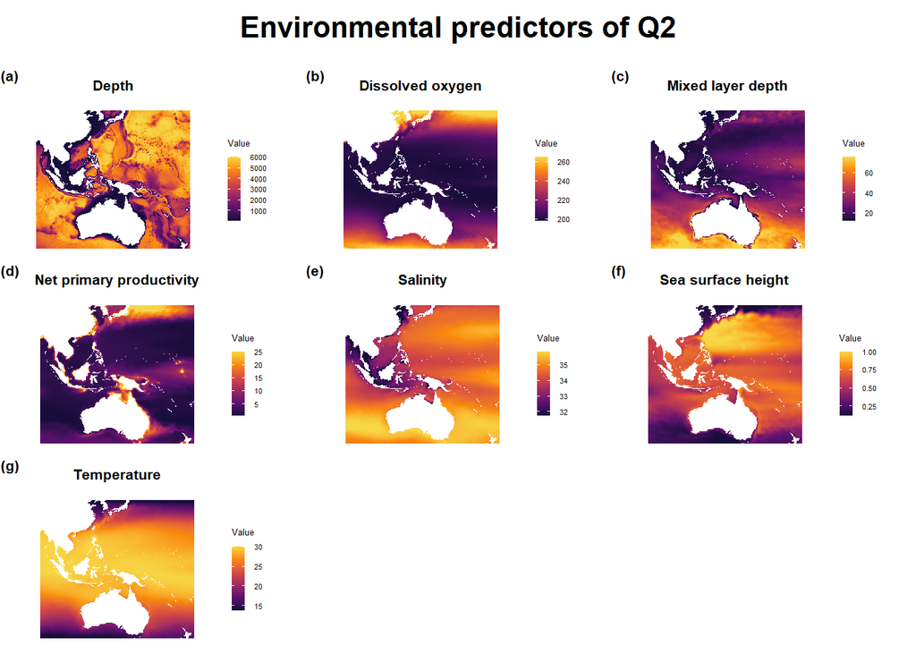

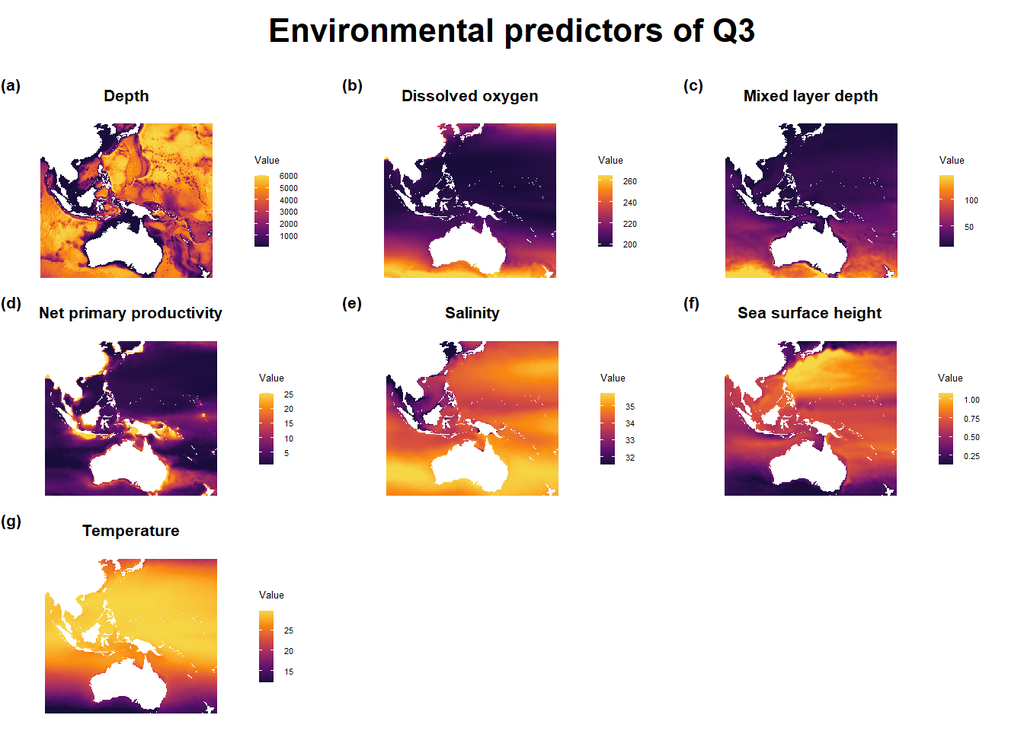

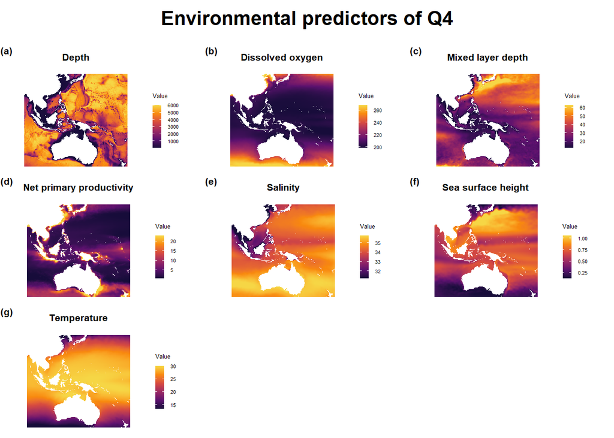

```r
# Load required packages
library(terra)
library(ggplot2)
library(cowplot)
library(dplyr)
library(scales)   # for squish

# Main directory and quarters
main_dir <- "F:/whaleshark_sdm/bin"
quarters <- c("Q1", "Q2", "Q3", "Q4")

# Loop over each quarter
for (q in quarters) {
  quarter_path <- file.path(main_dir, q)

  # Read all .asc files in the quarter folder
  files <- list.files(quarter_path, pattern = "\\.asc$", full.names = TRUE,
             ignore.case = TRUE)
  r <- rast(files)
  names(r) <- tools::file_path_sans_ext(basename(files))

  n_layers <- nlyr(r)

## Convert raster layers to a data frame for ggplot
  df_list <- list()
  for (i in 1:n_layers) {
    df <- as.data.frame(r[[i]], xy = TRUE, na.rm = FALSE)
    colnames(df) <- c("x", "y", "value")
    df$variable <- names(r)[i]
    df_list[[i]] <- df
  }
  df_all <- bind_rows(df_list)

# Create a list of ggplot objects with external labels
  gg_list <- list()
  for (i in 1:n_layers) {
    layer_name <- names(r)[i]
    df_sub <- filter(df_all, variable == layer_name)
## Compute 2% and 98% percentiles for color stretching (percent clip)
    values_vec <- df_sub$value[!is.na(df_sub$value)]
    if (length(values_vec) > 0) {
      p2 <- quantile(values_vec, 0.02, na.rm = TRUE)
      p98 <- quantile(values_vec, 0.98, na.rm = TRUE)
      # If p2 == p98, avoid identical limits; use full range
      if (p2 == p98) {
        p2 <- min(values_vec, na.rm = TRUE)
        p98 <- max(values_vec, na.rm = TRUE)
      }
    } else {
      p2 <- 0; p98 <- 1  # fallback
    }

    p <- ggplot(df_sub, aes(x = x, y = y, fill = value)) +
      geom_raster() +
      scale_fill_viridis_c(
        option = "inferno",
        begin = 0.1,
        end = 0.9,
        limits = c(p2, p98),      # percent clip range
        oob = squish,            # squish extremes to the nearest limit color
        na.value = "transparent"
      ) +
      coord_fixed() +
      labs(title = layer_name, fill = "Value") +
      theme_minimal() +
      theme(
        plot.title = element_text(size =8, face = "bold", hjust = 0.5),
        legend.position = "right",
        legend.key.size = unit(0.25, "cm"),
        legend.text = element_text(size = 4),
        legend.title = element_text(size = 5),
        legend.spacing = unit(0.1, "cm"),
        axis.text = element_blank(),
        axis.title = element_blank(),
        axis.ticks = element_blank(),
        panel.grid = element_blank(),
        plot.margin = ggplot2::margin(t = 5, r = 5, b = 5, l = 5, unit = "pt")
      )

    ggdraw_obj <- ggdraw(p) +
      draw_label(
        label = paste0("(", letters[i], ")"),
        x = 0, y = 1,
        hjust = -0.05,
        vjust = 1,
        size = 8,
        fontface = "bold"
      )
    gg_list[[i]] <- ggdraw_obj
  }

## Arrange subplots
  ncol <- ceiling(sqrt(n_layers))
  nrow <- ceiling(n_layers / ncol)
  combined <- plot_grid(plotlist = gg_list,
                 ncol = ncol, nrow = nrow, align = "hv")

## Create title with "Environmental predictors of QX" and separate by ~2 lines
  title_text <- paste0("Environmental predictors of ", q)
  title_gg <- ggdraw() +
    draw_label(title_text, x = 0.5, y = 0.5, size = 16, fontface = "bold") +
    theme(plot.margin = ggplot2::margin(b = 20, t = 10, unit = "pt"))

#   # Combine title and plot vertically
  final_plot <- plot_grid(title_gg, combined, ncol = 1,
                  rel_heights = c(0.12, 1), align = "v")

## Display the plot
  print(final_plot)
}
```

## 1.3 Adjust occurrence coordinates with correct_ob()

Our previous SDM studies often find that some occurrences were not spatially matched with the environmental layer but these points fall within a close distance to the environmental layer. Here I showed an example with temperature of the 1st quarter bin

```r
#### 1st quarter
temperature_raster_path <- "F:/whaleshark_sdm/bin/Q1/Temperature.asc"
final_combined_data<-read.csv("F:/whaleshark_sdm/occ/R_typus.csv")
str(final_combined_data)
```

```
#> 'data.frame':    5295 obs. of  8 variables:
#>  $ Species         : chr  "Rhincodon typus" "Rhincodon typus" "Rhincodon typus" "Rhincodon typus" ...
#>  $ decimalLatitude : num  10.1 -15.5 10.1 -36.3 -35.5 ...
#>  $ decimalLongitude: num  125.1 145.6 99.9 175.3 174.8 ...
#>  $ depth           : num  NA NA NA NA NA NA NA NA NA NA ...
#>  $ date            : int  19727 19739 19741 19747 19728 19753 19726 19726 19726 19726 ...
#>  $ year            : int  2024 2024 2024 2024 2024 2024 2024 2024 2024 2024 ...
#>  $ month           : int  1 1 1 1 1 1 1 1 1 1 ...
#>  $ day             : int  5 17 19 25 6 31 4 4 4 4 ...
```

```r
output_path<-"F:/whaleshark_sdm/occ/R_typus_adj.csv"
corrected_ob <- correct_ob(
  occurrence_data = final_combined_data,
  predictor_raster_path = temperature_raster_path,
  max_distance_km = 10,
  out_dir = output_path,
  verbose = TRUE
)
```

[output not shown]

```r
summary(corrected_ob)
```

```
#>    Species          decimalLatitude  decimalLongitude     depth            date
#>  Length:5279        Min.   :-37.44   Min.   : 94.01   Min.   : 0.00   Min.   :16440
#>  Class :character   1st Qu.:-22.60   1st Qu.:112.90   1st Qu.:30.00   1st Qu.:16741
#>  Mode  :character   Median :-20.31   Median :113.78   Median :56.00   Median :17393
#>                     Mean   :-17.98   Mean   :113.84   Mean   :46.58   Mean   :17554
#>                     3rd Qu.:-13.40   3rd Qu.:115.03   3rd Qu.:74.00   3rd Qu.:17772
#>                     Max.   : 23.28   Max.   :176.26   Max.   :86.00   Max.   :20085
#>                                                       NA's   :4934
#>       year          month             day          original_x       original_y
#>  Min.   :2015   Min.   : 1.000   Min.   : 1.00   Min.   : 94.01   Min.   :-37.44
#>  1st Qu.:2015   1st Qu.: 5.000   1st Qu.: 8.00   1st Qu.:112.90   1st Qu.:-22.60
#>  Median :2017   Median : 8.000   Median :15.00   Median :113.76   Median :-20.31
#>  Mean   :2018   Mean   : 7.268   Mean   :15.52   Mean   :113.84   Mean   :-17.99
#>  3rd Qu.:2018   3rd Qu.:10.000   3rd Qu.:24.00   3rd Qu.:115.03   3rd Qu.:-13.40
#>  Max.   :2024   Max.   :12.000   Max.   :31.00   Max.   :176.26   Max.   : 23.28
#>                                  NA's   :26
#>  correction_status  correction_distance_km  correction_x     correction_y
#>  Length:5279        Min.   : 0.000         Min.   : 94.11   Min.   :-28.324
#>  Class :character   1st Qu.: 0.000         1st Qu.:113.25   1st Qu.:-25.600
#>  Mode  :character   Median : 0.000         Median :113.80   Median :-22.224
#>                     Mean   : 1.908         Mean   :115.89   Mean   :-15.934
#>                     3rd Qu.: 0.000         3rd Qu.:117.87   3rd Qu.: -8.415
#>                     Max.   :27.753         Max.   :136.38   Max.   : 16.242
#>                                            NA's   :4916     NA's   :4916
#>   temperature
#>  Min.   :20.43
#>  1st Qu.:26.49
#>  Median :27.67
#>  Mean   :27.51
#>  3rd Qu.:29.09
#>  Max.   :30.82
#>
```

```r
## Plot the occurrences in the map of sea surface temperature of the first quarter and IUCN range map
# setwd("F:/whaleshark_sdm/figures")
corrected_ob<-read.csv("F:/whaleshark_sdm/occ/R_typus_adj.csv")
corrected_ob1<-corrected_ob[which(corrected_ob$month<4),]
head(corrected_ob1)
```

```
#>           Species decimalLatitude decimalLongitude depth  date year month day original_x
#> 1 Rhincodon typus      10.1426900        125.36579    NA 19727 2024     1   5  125.11648
#> 2 Rhincodon typus     -15.5001300        145.63711    NA 19739 2024     1  17  145.63711
#> 3 Rhincodon typus      10.1189500         99.93454    NA 19741 2024     1  19   99.93454
#> 4 Rhincodon typus     -36.2664700        175.26819    NA 19747 2024     1  25  175.26819
#> 5 Rhincodon typus     -35.4795100        174.81567    NA 19728 2024     1   6  174.81567
#> 6 Rhincodon typus       0.3449025        123.18909    NA 19753 2024     1  31  123.18909
#>   original_y correction_status correction_distance_km correction_x correction_y
#> 1   10.14269         corrected               27.75291     125.3658   10.1426900
#> 2  -15.50013          original                0.00000           NA           NA
#> 3   10.11895          original                0.00000           NA           NA
#> 4  -36.26647          original                0.00000           NA           NA
#> 5  -35.47951          original                0.00000           NA           NA
#> 6    0.59421         corrected               27.75291     123.1891    0.3449025
#>   temperature
#> 1    27.91688
#> 2    29.21610
#> 3    28.49581
#> 4    21.08163
#> 5    21.43488
#> 6    29.60550
```

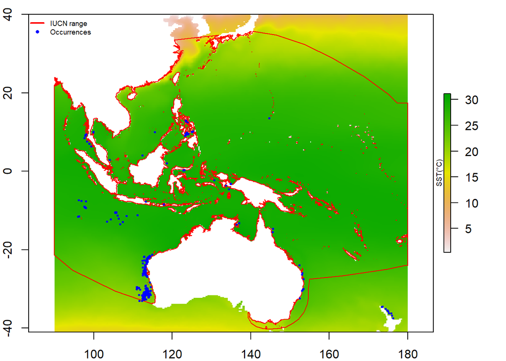

```r
# tiff("Q1_sst_points.tif",width=1317,height = 880,res = 300)
par(mar=c(2,2,1,1))
plot(raster::raster(temperature_raster_path),legend.args = list(text = 'SST(°C)',cex=0.6,side=2),cex=0.5)
range_path<-"F:/whaleshark_sdm/range_map/R_typus_wip2.shp"
plot(sf::st_read(range_path)$geometry,add=T,border="red",lwd=1)
points(corrected_ob1$decimalLongitude,corrected_ob1$decimalLatitude,pch=20,col="blue",cex=0.5)
legend("topleft",
       legend = c("IUCN range", "Occurrences"),
       col = c("red", "blue"),
       lwd = c(2, NA),
       pch = c(NA, 16),
       bty = "n",
       cex=0.6)
```

```r
# dev.off()

#### 2nd quarter

# corrected_ob<-read.csv("F:/whaleshark_sdm/occ/R_typus_adj.csv")
# corrected_ob2<-corrected_ob[which((corrected_ob$month>3) & (corrected_ob$month<7)),]
#  head(corrected_ob2)
# tiff("Q2_sst_points.tif",width=1317,height = 880,res = 300)
# par(mar=c(2,2,1,1))
# plot(raster::raster(temperature_raster_path),legend.args = list(text = 'SST(°C)',cex=0.6,side=2))
# range_path<-"F:/whaleshark_sdm/range_map/R_typus_wip2.shp"
# plot(sf::st_read(range_path)$geometry,add=T,border="red",lwd=1)
# points(corrected_ob2$decimalLongitude,corrected_ob2$decimalLatitude,pch=20,col="blue",cex=0.5)
# legend("topleft",
#        legend = c("IUCN range", "Occurrences"),
#        col = c("red", "blue"),
#        lwd = c(2, NA),
#        pch = c(NA, 16),
#        bty = "n",
#        cex=0.6)
# dev.off()

#### 3rd quarter

# corrected_ob<-read.csv("F:/whaleshark_sdm/occ/R_typus_adj.csv")
# corrected_ob3<-corrected_ob[which((corrected_ob$month>6) & (corrected_ob$month<10)),]
# head(corrected_ob3)
#  tiff("Q3_sst_points.tif",width=1317,height = 880,res = 300)
# par(mar=c(2,2,1,1))
# plot(raster::raster(temperature_raster_path),legend.args = list(text = 'SST(°C)',cex=0.6,side=2))
# range_path<-"F:/whaleshark_sdm/range_map/R_typus_wip2.shp"
# plot(sf::st_read(range_path)$geometry,add=T,border="red",lwd=1)
# points(corrected_ob3$decimalLongitude,corrected_ob3$decimalLatitude,pch=20,col="blue",cex=0.5)
# legend("topleft",
#        legend = c("IUCN range", "Occurrences"),
#        col = c("red", "blue"),
#        lwd = c(2, NA),
#        pch = c(NA, 16),
#        bty = "n",
#        cex=0.6)
#  dev.off()
#
#### 4th quarter
#
# corrected_ob<-read.csv("F:/whaleshark_sdm/occ/R_typus_adj.csv")
# corrected_ob4<-corrected_ob[which(corrected_ob$month>9),]
# head(corrected_ob4)
# # tiff("Q4_sst_points.tif",width=1317,height = 880,res = 300)
# par(mar=c(2,2,1,1))
# plot(raster::raster(temperature_raster_path),legend.args = list(text = 'SST(°C)',cex=0.6,side=2))
# range_path<-"F:/whaleshark_sdm/range_map/R_typus_wip2.shp"
# plot(sf::st_read(range_path)$geometry,add=T,border="red",lwd=1)
# points(corrected_ob4$decimalLongitude,corrected_ob4$decimalLatitude,pch=20,col="blue",cex=0.5)
# legend("topleft",
#        legend = c("IUCN range", "Occurrences"),
#        col = c("red", "blue"),
#        lwd = c(2, NA),
#        pch = c(NA, 16),
#        bty = "n",
#        cex=0.6)
#  dev.off()
```

## 1.4 Check and remove spatio-temporal bias with bias_check() and bias_reduce()

Spatio-temporal sampling bias is a common issue in global biodiversity data and it degrades model robustness. Here, bias_check() and bias_reduce() are two functions to examine and reduce sampling bias (see details in Supplementary Information), respectively, adapted from the dynamicSDM (Dobson et al., 2023).

Although designed for highly-mobile marine fish, these data-preparation functions can apply broadly to other marine species.

```r
colnames(corrected_ob)
```

```
#>  [1] "Species"                "decimalLatitude"        "decimalLongitude"
#>  [4] "depth"                  "date"                   "year"
#>  [7] "month"                  "day"                    "original_x"
#> [10] "original_y"             "correction_status"      "correction_distance_km"
#> [13] "correction_x"           "correction_y"           "temperature"
```

```r
occ_ob<-corrected_ob[,c(1:8)]
colnames(occ_ob)[2:3]<-c("y","x")
#### For the quarterly SDMs
occ_ob2 <- occ_ob %>%
  mutate(
         quarter = case_when(
           month %in% 1:3   ~ "Q1",
           month %in% 4:6   ~ "Q2",
           month %in% 7:9  ~ "Q3",
           month %in% 10:12 ~ "Q4",
           TRUE ~ NA_character_
         ))%>% filter(!is.na(quarter))
table(occ_ob2$quarter)
```

```
#>
#>   Q1   Q2   Q3   Q4
#>  923  685 2255 1416
```

```r
#### For the seasonal SDMs
# occ_ob3 <- occ_ob2 %>%
#  mutate(date = make_date(year, month, day),
#         adjusted_date = date - days(73),
# # Parse date information and adjust for sea temperature lag (73 days)
#         adjusted_month = month(adjusted_date),
#         hemisphere = ifelse(y >= 0, "Northern", "Southern"),
#         season = case_when(
#           hemisphere == "Northern" & adjusted_month %in% 3:5   ~ "Spring",
#           hemisphere == "Northern" & adjusted_month %in% 6:8   ~ "Summer",
#           hemisphere == "Northern" & adjusted_month %in% 9:11  ~ "Autumn",
 #          hemisphere == "Northern" & adjusted_month %in% c(12,1,2) ~ "Winter",
  #         hemisphere == "Southern" & adjusted_month %in% 3:5   ~ "Autumn",
  #         hemisphere == "Southern" & adjusted_month %in% 6:8   ~ "Winter",
  #         hemisphere == "Southern" & adjusted_month %in% 9:11  ~ "Spring",
#           hemisphere == "Southern" & adjusted_month %in% c(12,1,2) ~ "Summer",
#           TRUE ~ NA_character_
#         ))
# occ_ob2 <- occ_ob3 %>% filter(!is.na(season))
range_path<-"F:/whaleshark_sdm/range_map/R_typus_wip2.shp"
bias_test<-bias_check(occ_data=occ_ob2,
                        temporal_level="quarter",
                        spatial_method="range_map",
                        range_path=range_path,
                        prj = "+proj=longlat +datum=WGS84")
```

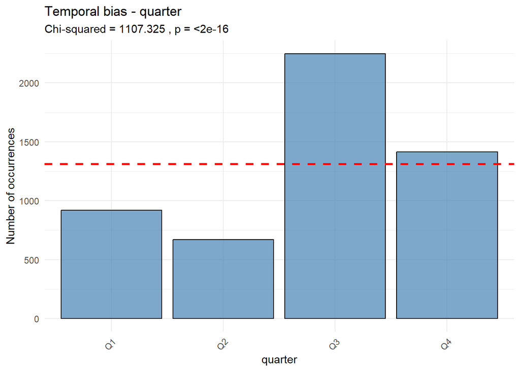

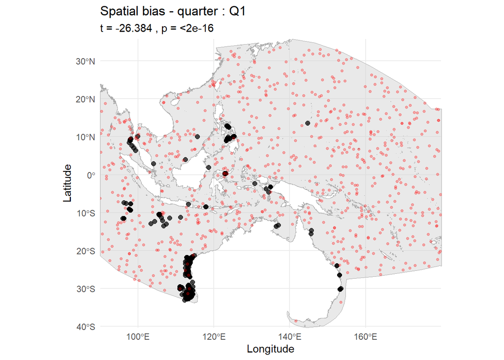

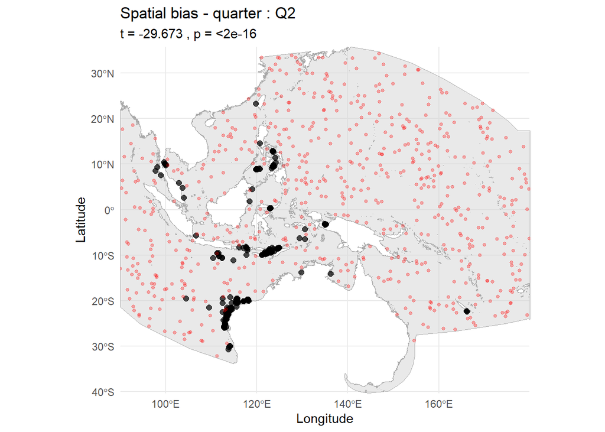

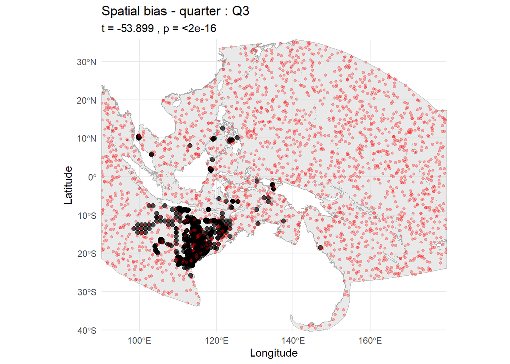

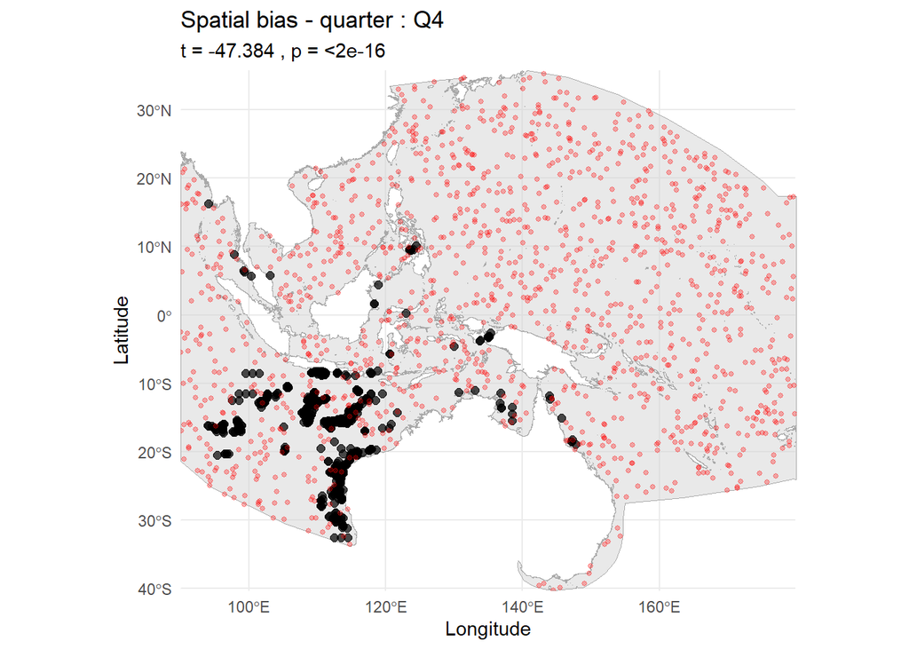

```r
bias_test$Plots
```

```r
occ_thinned<-bias_reduce(occ_data=occ_ob2,
                           bias_result=bias_test,
                  min_dist_km = 56,
                          thin_reps = 50,
                          temporal_level = "quarter",
                          seed = 123)
```

```
#> Temporal bias test p-value: 0
#>
#> === Step 1: Spatial thinning ===
#> Quarter Q1 spatial bias p-value: 0
#> Quarter Q1 has spatial bias, performing thinning...
#> Quarter Q1 thinning completed. Original points: 923
#> Points after thinning: 130
#> Quarter Q2 spatial bias p-value: 0
#> Quarter Q2 has spatial bias, performing thinning...
#> Quarter Q2 thinning completed. Original points: 685
#> Points after thinning: 102
#> Quarter Q3 spatial bias p-value: 0
#> Quarter Q3 has spatial bias, performing thinning...
#> Quarter Q3 thinning completed. Original points: 2255
#> Points after thinning: 273
#> Quarter Q4 spatial bias p-value: 0
#> Quarter Q4 has spatial bias, performing thinning...
#> Quarter Q4 thinning completed. Original points: 1416
#> Points after thinning: 186
#>
#> === Step 2: Temporal balancing ===
#> Temporal bias detected, performing temporal balancing...
#> Quarter with smallest sample size: Q2 sample size: 102
#> Quarter Q1 sampled from 130 points to 102 points
#> Quarter Q2 keeping 102 points
#> Quarter Q3 sampled from 273 points to 102 points
#> Quarter Q4 sampled from 186 points to 102 points
#>
#> Sample sizes per quarter after balancing:
#> Quarter Q1 : 102
#> Quarter Q2 : 102
#> Quarter Q3 : 102
#> Quarter Q4 : 102
#>
#> === Thinning summary ===
#> Original total sample size: 5279
#> Sample size after spatial thinning: 691
#> Final sample size: 408
#> Retention ratio: 7.73 %
#>
#> Retention ratio per quarter:
#> Quarter Q1 :  923  ->  102  ( 11.05 %)
#> Quarter Q2 :  685  ->  102  ( 14.89 %)
#> Quarter Q3 :  2255  ->  102  ( 4.52 %)
#> Quarter Q4 :  1416  ->  102  ( 7.2 %)
```

```r
bias_test<-bias_check(occ_data=occ_thinned,
                        temporal_level="quarter",
                        spatial_method="range_map",
                        range_path=range_path,
                        prj = "+proj=longlat +datum=WGS84")

```

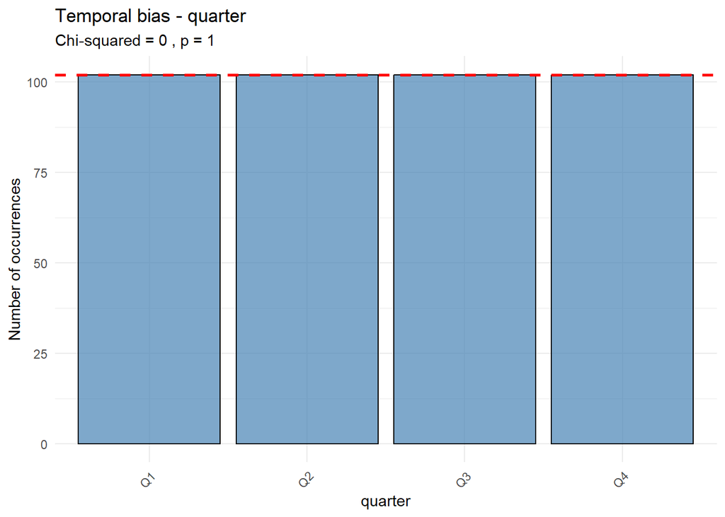

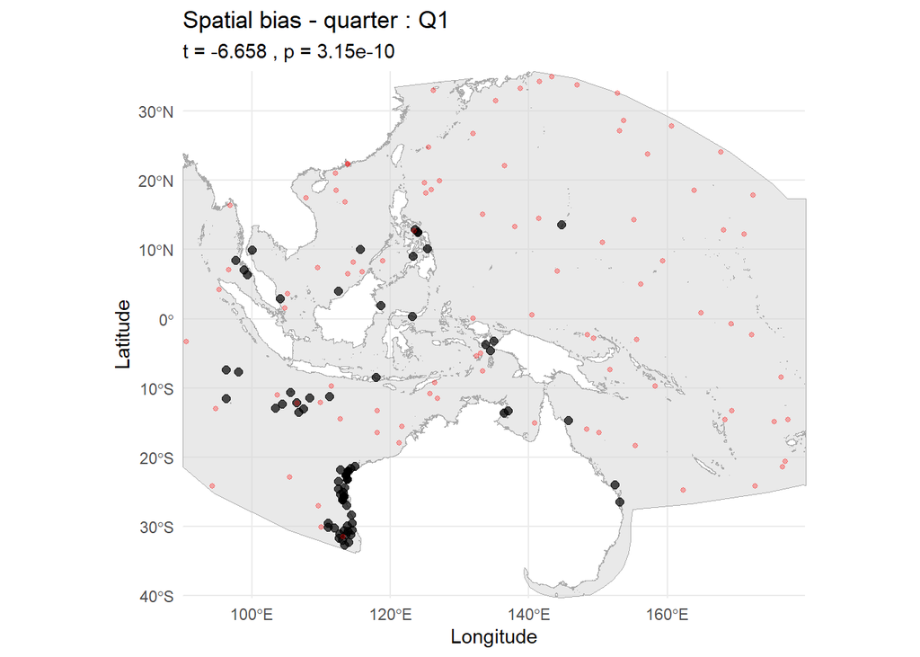

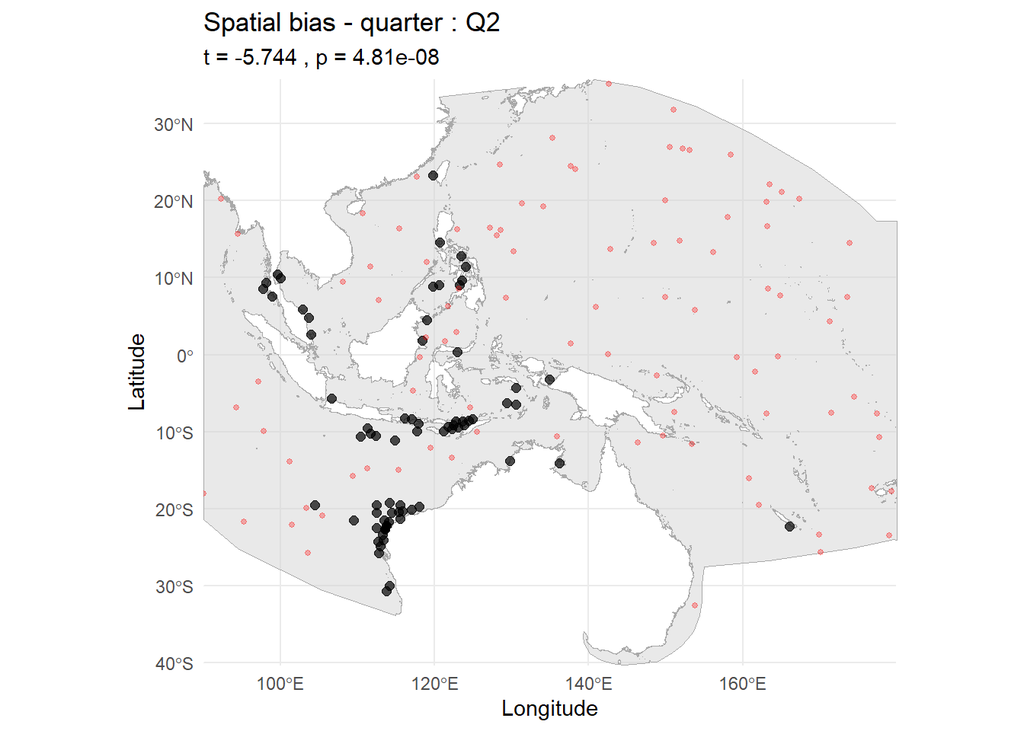

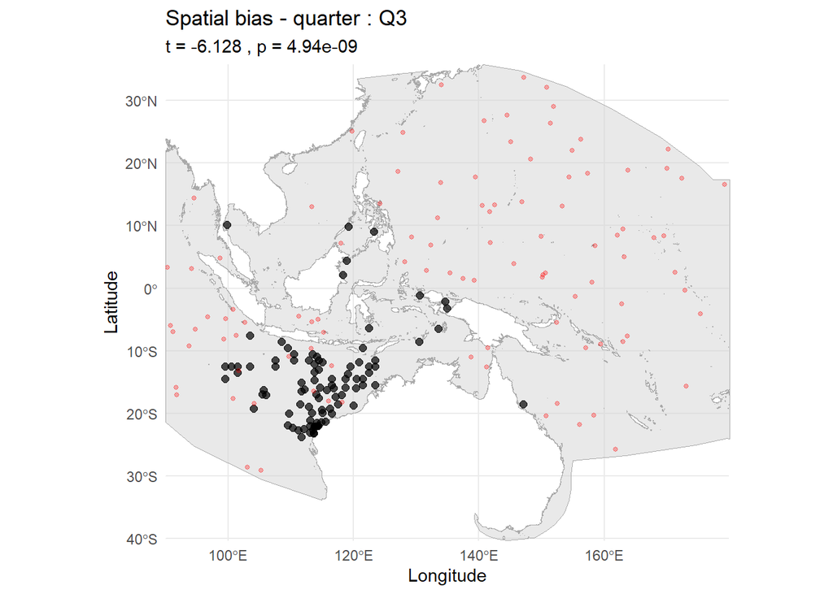

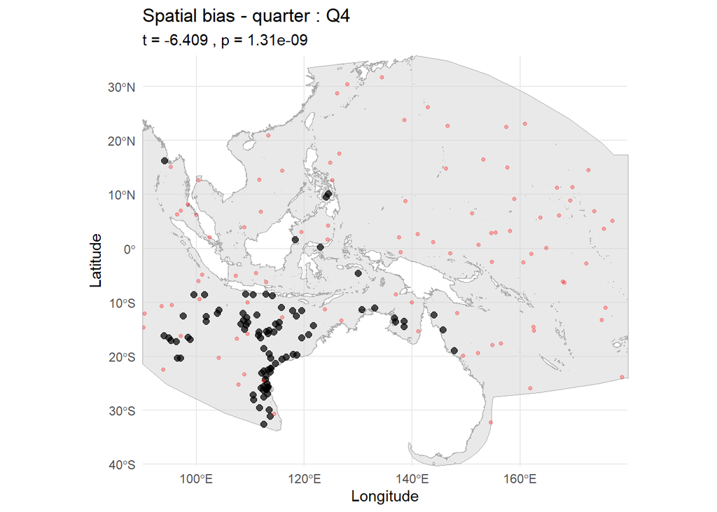

```r
bias_test$Plots
```

```r
## Note that the spatial bias still exist but have been largely reduced.
## A certain level of spatial autocorrelation of occurrences are ecological
## meaningful given species are rarely uniformly distributed in the ocean,
## and such autocorrelation is not problematic for machine-learning algorithms.

#### save the thinned occurrences
# write.table(occ_thinned, "F:/whaleshark_sdm/occ/R_typus.txt",
#   append = FALSE, sep = "\t", dec = ".",row.names = FALSE, col.names = TRUE)
# occ_q1<-occ_thinned[which(occ_thinned$quarter=="Q1"),]
# write.table(occ_q1, "F:/whaleshark_sdm/occ/R_typus_q1.txt",
#   append = FALSE, sep = "\t", dec = ".",row.names = FALSE, col.names = TRUE)
# occ_q2<-occ_thinned[which(occ_thinned$quarter=="Q2"),]
# write.table(occ_q2, "F:/whaleshark_sdm/occ/R_typus_q2.txt",
#    append = FALSE, sep = "\t", dec = ".",row.names = FALSE, col.names = TRUE)
# occ_q3<-occ_thinned[which(occ_thinned$quarter=="Q3"),]
# write.table(occ_q3, "F:/whaleshark_sdm/occ/R_typus_q3.txt",
#    append = FALSE, sep = "\t", dec = ".",row.names = FALSE, col.names = TRUE)
# occ_q4<-occ_thinned[which(occ_thinned$quarter=="Q4"),]
# write.table(occ_q4, "F:/whaleshark_sdm/occ/R_typus_q4.txt",
#    append = FALSE, sep = "\t", dec = ".", row.names = FALSE, col.names = TRUE)
```

# 2. Build 2D SDMs for each temporal bin and generate related figures

## 2.1 SDM construction for each quarter with TB_sdm()

```r
#### Prior to this step, please rename the environmental predictors to make the
#### the names of variables of each quarterly bin the same as follows:
#### Depth, Mixed layer depth, Dissolved oxygen, Temperature, Salinity,
####      Net primary productivity, Sea surface height.
####  Name the folders of each bin as Q1, Q2, Q3, and Q4.
####
# if (!"devtools"%in%installed.packages()){install.packages("devtools")}
# devtools::install_github("andrefaa/ENMTML")
## Q1
d_env<-"F:/whaleshark_sdm/bin/Q1"  #
d_prj<-"F:/whaleshark_sdm/bin/proj"  #
d_occ<-"F:/whaleshark_sdm/occ/R_typus_q1.txt" #
d_res<-"F:/whaleshark_sdm/result_sdm/Q1"

sdm_q1<-TB_sdm(env_path=d_env,prj_path=d_prj,occ_path=d_occ,
                 eval_occ=NULL,res_path=d_res,species="Species",x="x",y="y",
                 colin_var=NULL,
                 sp_accessible_area=NULL,
                 pseudoabs_method=c(method='ENV_CONST'),
                 pres_abs_ratio=0.3,
                 part= c(method='BLOCK'),
                 algorithm=c('BRT','SVM','RDF','MXD'),
                 thr=c(type = 'MAX_TSS'),
                 ensemble=c(method='SUP', metric='TSS'))
```

```
#> Checking for function arguments ...
#> Loading environmental variables ...
#> RasterBrick successfully created!
#> Loading and processing species occurrence data ...
#> Result folder already exists, files may be overwritten!
#> Warning in dir.create(DirR, recursive = T):
#> 'F:\whaleshark_sdm\result_sdm\Q1' already exists
#> Results can be found at:
#> F:/whaleshark_sdm/result_sdm/Q1
#> Performing partition of species occurrence data ...
#> Partition Already Exist! Using pre-created partitions!
#> Total species to be modeled 1
#> Fitting Models....
#> Models fitted!
#> Performing Ensemble....
#> Ensemble created!
#> Models were created successfully!
#>  Outputs are in:
#>  F:/whaleshark_sdm/result_sdm/Q1Model evaluation table:
#>   Algorithm       AUC       TSS         OR     AUC_SD     TSS_SD
#> 1       MXD 0.9370597 0.7530964 0.07717803 0.04773529 0.09651714
#> 2       SVM 0.9135737 0.7380217 0.01515152 0.08386809 0.26376013
#> 3       RDF 0.9289981 0.7932533 0.01515152 0.09165634 0.23901746
#> 4       BRT 0.9358454 0.8074167 0.04592803 0.05945884 0.13476823
#> 5       SUP 0.9292857 0.7868907 0.03077652 0.08582959 0.21716294
#>          OR_SD
#> 1 0.0234363043
#> 2 0.0214274782
#> 3 0.0214274782
#> 4 0.0207578695
#> 5 0.0006696087
#> Start reading variable importance data......
#> Variable importance table:
#> 'data.frame':    420 obs. of  4 variables:
#>  $ Sp : chr  "Rhincodon_typus" "Rhincodon_typus" "Rhincodon_typus" "Rhincodon_typus" ...
#>  $ Al : chr  "BRT" "BRT" "BRT" "BRT" ...
#>  $ Var: chr  "Depth" "Dissolved.oxygen" "Mixed.layer.depth" "Net.primary.productivity" ...
#>  $ Im : num  0.2291 0.1723 0.4135 0.0865 0.0554 ...
#> Done......variable importance plot was successfully created!
#> Create response curves based on package 'sdm'.......
#> The id argument is not specified; The modelIDs of 4 successfully fitted models are assigned to id...!
#> Warning: Using `size` aesthetic for lines was deprecated in ggplot2 3.4.0.
#> ℹ Please use `linewidth` instead.
#> ℹ The deprecated feature was likely used in the sdm package.
#>   Please report the issue to the authors.
#> was generated.
```

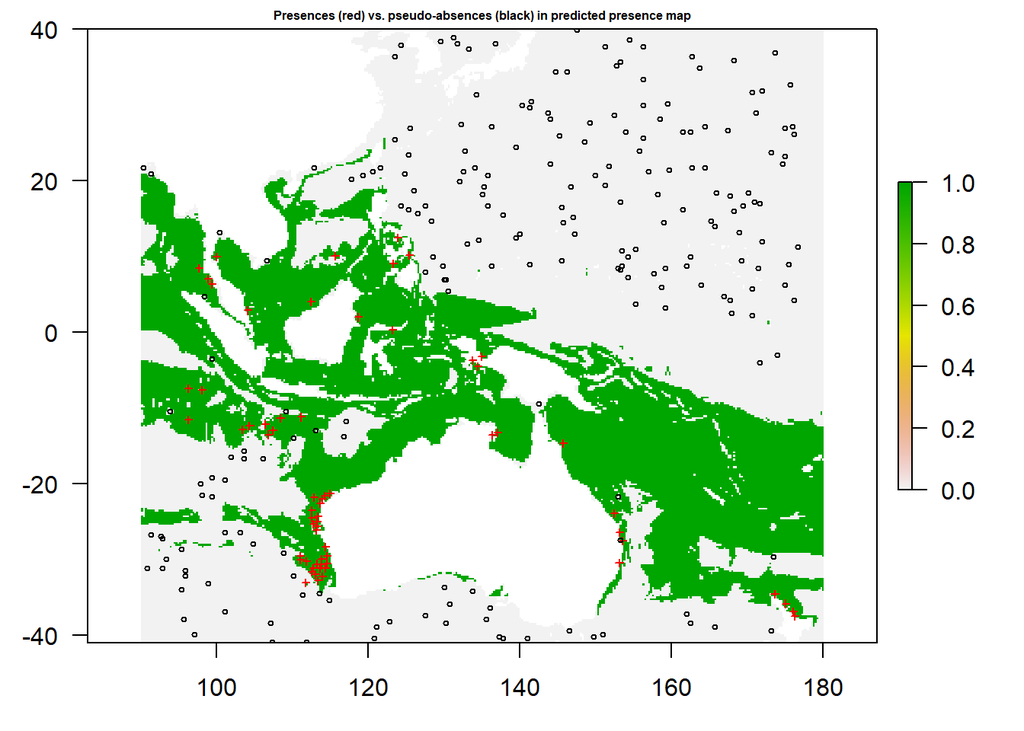

```
#> Done......response curves were successfully created!
## Q2
d_env<-"F:/whaleshark_sdm/bin/Q2"  #
d_occ<-"F:/whaleshark_sdm/occ/R_typus_q2.txt" #
d_res<-paste("F:/whaleshark_sdm/result_sdm/Q2") #

sdm_q2<-TB_sdm(env_path=d_env,prj_path=NULL,occ_path=d_occ,
       eval_occ=NULL,res_path=d_res,species="Species",x="x",y="y",
       colin_var=NULL,
       sp_accessible_area=NULL,
       pseudoabs_method=c(method='ENV_CONST'),
       pres_abs_ratio=0.3,
       part= c(method='BLOCK'),
       algorithm=c('BRT','SVM','RDF','MXD'),
       thr=c(type = 'MAX_TSS'),
       ensemble=c(method='SUP', metric='TSS'))
#> Checking for function arguments ...
#> Loading environmental variables ...
#> RasterBrick successfully created!
#> Loading and processing species occurrence data ...
#> Result folder already exists, files may be overwritten!
#> Warning in dir.create(DirR, recursive = T):
#> 'F:\whaleshark_sdm\result_sdm\Q2' already exists
#> Results can be found at:
#> F:/whaleshark_sdm/result_sdm/Q2
#> Performing partition of species occurrence data ...
#> Partition Already Exist! Using pre-created partitions!
#> Total species to be modeled 1
#> Fitting Models....
#> Models fitted!
#> Performing Ensemble....
#> Ensemble created!
#> Models were created successfully!
#>  Outputs are in:
#>  F:/whaleshark_sdm/result_sdm/Q2Model evaluation table:
#>   Algorithm       AUC       TSS         OR      AUC_SD     TSS_SD
#> 1       MXD 0.9615941 0.8594896 0.06515152 0.044574427 0.09157428
#> 2       SVM 0.9509181 0.8037224 0.07765152 0.009804939 0.01616325
#> 3       RDF 0.9576057 0.8703606 0.03750000 0.004243205 0.02906001
#> 4       BRT 0.9387371 0.8475478 0.06250000 0.005604025 0.03560909
#> 5       SUP 0.9737440 0.8824248 0.03750000 0.024275077 0.02485507
#>        OR_SD
#> 1 0.04928320
#> 2 0.06696087
#> 3 0.05303301
#> 4 0.08838835
#> 5 0.05303301
#> Start reading variable importance data......
#> Variable importance table:
#> 'data.frame':    392 obs. of  4 variables:
#>  $ Sp : chr  "Rhincodon_typus" "Rhincodon_typus" "Rhincodon_typus" "Rhincodon_typus" ...
#>  $ Al : chr  "BRT" "BRT" "BRT" "BRT" ...
#>  $ Var: chr  "Depth" "Dissolved.oxygen" "Mixed.layer.depth" "Net.primary.productivity" ...
#>  $ Im : num  0.2052 0.1407 0.0802 0.0519 0.31 ...
#> Done......variable importance plot was successfully created!
```

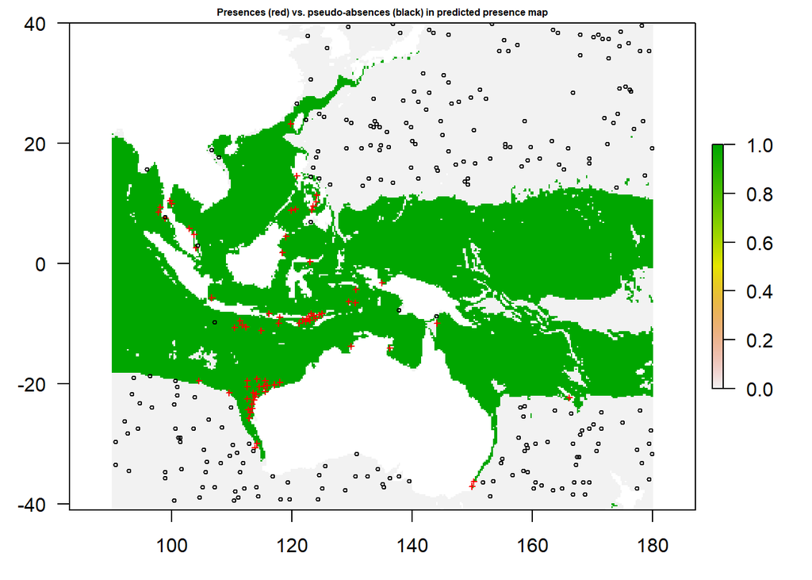

```
#> Create response curves based on package 'sdm'.......
#> The id argument is not specified; The modelIDs of 4 successfully fitted models are assigned to id...!
#> Done......response curves were successfully created!
## Q3
d_env<-"F:/whaleshark_sdm/bin/Q3"  #
d_occ<-"F:/whaleshark_sdm/occ/R_typus_q3.txt" #
d_res<-paste("F:/whaleshark_sdm/result_sdm/Q3") #

sdm_q3<-TB_sdm(env_path=d_env,prj_path=NULL,occ_path=d_occ,
       eval_occ=NULL,res_path=d_res,species="Species",x="x",y="y",
       colin_var=NULL,
       sp_accessible_area=NULL,
       pseudoabs_method=c(method='ENV_CONST'),
       pres_abs_ratio=0.3,
       part= c(method='BLOCK'),
       algorithm=c('BRT','SVM','RDF','MXD'),
       thr=c(type = 'MAX_TSS'),
       ensemble=c(method='SUP', metric='TSS'))
#> Checking for function arguments ...
#> Loading environmental variables ...
#> RasterBrick successfully created!
#> Loading and processing species occurrence data ...
#> Result folder already exists, files may be overwritten!
#> Warning in dir.create(DirR, recursive = T):
#> 'F:\whaleshark_sdm\result_sdm\Q3' already exists
#> Results can be found at:
#> F:/whaleshark_sdm/result_sdm/Q3
#> Performing partition of species occurrence data ...
#> Partition Already Exist! Using pre-created partitions!
#> Total species to be modeled 1
#> Fitting Models....
#> Models fitted!
#> Performing Ensemble....
#> Ensemble created!
#> Models were created successfully!
#>  Outputs are in:
#>  F:/whaleshark_sdm/result_sdm/Q3Model evaluation table:
#>   Algorithm       AUC       TSS          OR     AUC_SD     TSS_SD
#> 1       MXD 0.9031772 0.6566285 0.211170848 0.01587607 0.08752570
#> 2       SVM 0.8979842 0.6922916 0.114396655 0.06465898 0.13575784
#> 3       RDF 0.9123992 0.6873508 0.008064516 0.03367920 0.14359654
#> 4       BRT 0.8682426 0.6538504 0.056451613 0.07808459 0.14383276
#> 5       SUP 0.9241124 0.7348088 0.072580645 0.01198479 0.02934037
#>        OR_SD
#> 1 0.08912756
#> 2 0.04773182
#> 3 0.01140495
#> 4 0.07983464
#> 5 0.10264453
#> Start reading variable importance data......
#> Variable importance table:
#> 'data.frame':    392 obs. of  4 variables:
#>  $ Sp : chr  "Rhincodon_typus" "Rhincodon_typus" "Rhincodon_typus" "Rhincodon_typus" ...
#>  $ Al : chr  "BRT" "BRT" "BRT" "BRT" ...
#>  $ Var: chr  "Depth" "Dissolved.oxygen" "Mixed.layer.depth" "Net.primary.productivity" ...
#>  $ Im : num  0.04 0.4373 0.1062 0.0924 0.0483 ...
#> Done......variable importance plot was successfully created!
```

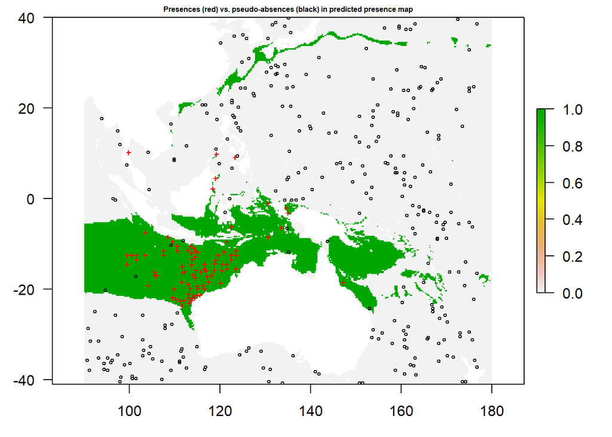

```
#> Create response curves based on package 'sdm'.......
#> The id argument is not specified; The modelIDs of 4 successfully fitted models are assigned to id...!
#> Done......response curves were successfully created!
## Q4
d_env<-"F:/whaleshark_sdm/bin/Q4"  #
d_occ<-"F:/whaleshark_sdm/occ/R_typus_q4.txt" #
d_res<-paste("F:/whaleshark_sdm/result_sdm/Q4") #

sdm_q4<-TB_sdm(env_path=d_env,prj_path=NULL,occ_path=d_occ,
       eval_occ=NULL,res_path=d_res,species="Species",x="x",y="y",
       colin_var=NULL,
       sp_accessible_area=NULL,
       pseudoabs_method=c(method='ENV_CONST'),
       pres_abs_ratio=0.3,
       part= c(method='BLOCK'),
       algorithm=c('BRT','SVM','RDF','MXD'),
       thr=c(type = 'MAX_TSS'),
       ensemble=c(method='SUP', metric='TSS'))
#> Checking for function arguments ...
#> Loading environmental variables ...
#> RasterBrick successfully created!
#> Loading and processing species occurrence data ...
#> Result folder already exists, files may be overwritten!
#> Warning in dir.create(DirR, recursive = T):
#> 'F:\whaleshark_sdm\result_sdm\Q4' already exists
#> Results can be found at:
#> F:/whaleshark_sdm/result_sdm/Q4
#> Performing partition of species occurrence data ...
#> Partition Already Exist! Using pre-created partitions!
#> Total species to be modeled 1
#> Fitting Models....
#> Models fitted!
#> Performing Ensemble....
#> Ensemble created!
#> Models were created successfully!
#>  Outputs are in:
#>  F:/whaleshark_sdm/result_sdm/Q4Model evaluation table:
#>   Algorithm       AUC       TSS         OR     AUC_SD    TSS_SD
#> 1       MXD 0.9412839 0.7783613 0.09453782 0.04190951 0.2023276
#> 2       SVM 0.8952022 0.7673669 0.11834734 0.02746919 0.0211934
#> 3       RDF 0.9300208 0.8164566 0.06862745 0.09367421 0.2090620
#> 4       BRT 0.8912824 0.7120448 0.18627451 0.13643301 0.2860118
#> 5       SUP 0.9389412 0.8054622 0.09453782 0.07937537 0.1741028
#>          OR_SD
#> 1 0.0326814059
#> 2 0.0009903456
#> 3 0.0970538719
#> 4 0.2634319381
#> 5 0.0326814059
#> Start reading variable importance data......
#> Variable importance table:
#> 'data.frame':    392 obs. of  4 variables:
#>  $ Sp : chr  "Rhincodon_typus" "Rhincodon_typus" "Rhincodon_typus" "Rhincodon_typus" ...
#>  $ Al : chr  "BRT" "BRT" "BRT" "BRT" ...
#>  $ Var: chr  "Depth" "Dissolved.oxygen" "Mixed.layer.depth" "Net.primary.productivity" ...
#>  $ Im : num  0.0505 0.4636 0.0704 0.1267 0.0311 ...
#> Done......variable importance plot was successfully created!
```

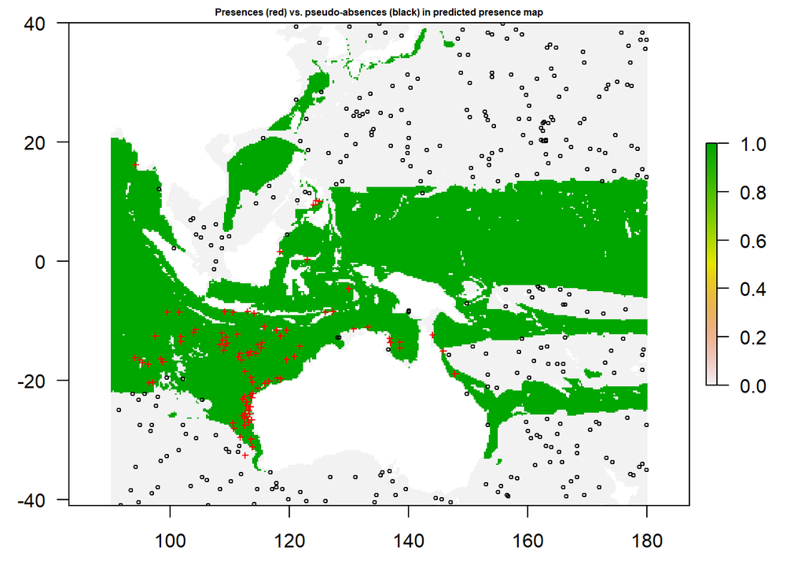

```
#> Create response curves based on package 'sdm'.......
#> The id argument is not specified; The modelIDs of 4 successfully fitted models are assigned to id...!
#> Done......response curves were successfully created!
## save data
# save(sdm_q1,sdm_q2,sdm_q3,sdm_q4, file = "F:/whaleshark_sdm/example.RData")
```

## 2.2 Plot predictive maps, variable importance and species response curves with TB_map(), TB_varimp(), and TB_rescur()

After successful 2D-SDM construction, TB_map(), TB_varimp(), and TB_rescur() automatically produces related figures (i.e., probability and binary maps, variable importance, and species response curves) required for publication.

```
#> Land background prepared.
#> Plot saved to: F:/whaleshark_sdm/result_sdm/SDM_quarterly.tif
```

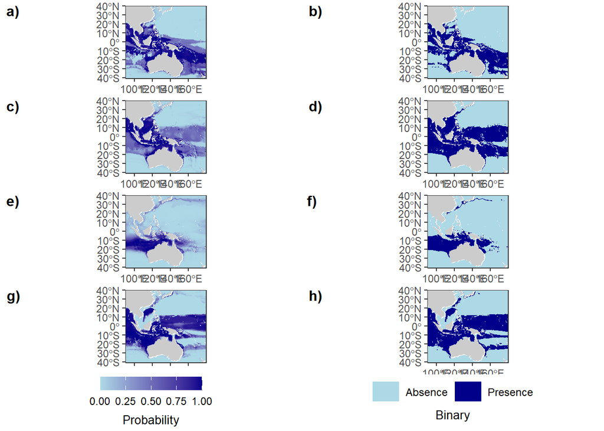

```r
rm(list = setdiff(ls(), c("sdm_q1", "sdm_q2", "sdm_q3", "sdm_q4")))
## plot predictive maps
TB_map(root_path = "F:/whaleshark_sdm/result_sdm",
                   output_width = 8, output_height = 12,
                   output_filename = "SDM_quarterly")
```

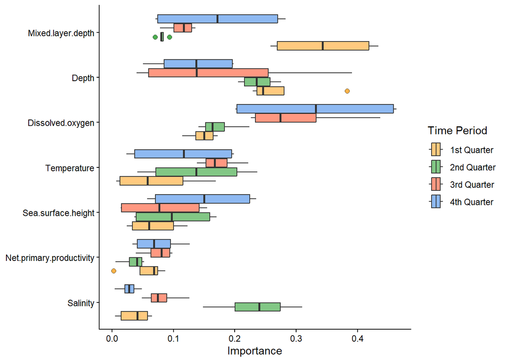

```r
# Prepare model list
# load("F:/whaleshark_sdm/example.RData")
rm(list = setdiff(ls(), c("sdm_q1", "sdm_q2", "sdm_q3", "sdm_q4")))
model_list <- list(
  Q1 = sdm_q1,
  Q2 = sdm_q2,
  Q3 = sdm_q3,
  Q4 = sdm_q4
)

# Name each temporal bin
time_names <- c("1st Quarter", "2nd Quarter", "3rd Quarter", "4th Quarter")

#  Plot variable importance
imp_plot <- TB_varimp(model_list,
                      colors = c("1st Quarter" = "#FFB347",
                                 "2nd Quarter" = "#4CAF50",
                                 "3rd Quarter" = "#FF6B4A",
                                 "4th Quarter" = "#5D9BEC"),
                      time_names = time_names,
                      save_path = "F:/whaleshark_sdm/result_sdm/variable_importance.tif")
imp_plot
```

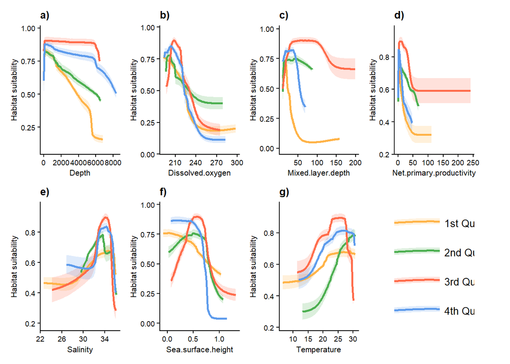

```r
#  Plot response curves panel (vertical stacked legend)
res_plot <- TB_rescur(model_list,
                      colors = c("1st Quarter" = "#FFB347",
                                 "2nd Quarter" = "#4CAF50",
                                 "3rd Quarter" = "#FF6B4A",
                                 "4th Quarter" = "#5D9BEC"),
                      time_names = time_names,
                      legend_position = "vertical",
                      width = 11,
                      height = 4,
                      save_path = "F:/whaleshark_sdm/result_sdm/response_curves.tif")
res_plot
```

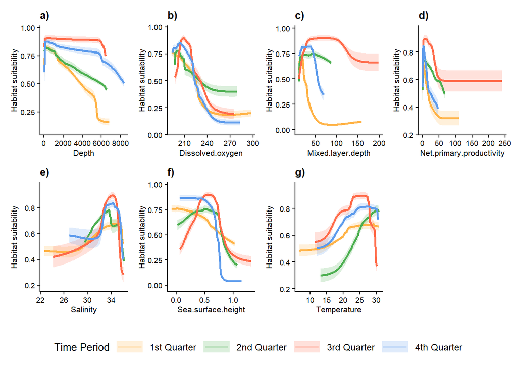

```r
#  Plot response curves panel (unified legend at bottom)
res_plot2 <- TB_rescur(model_list,
                       colors = c("1st Quarter" = "#FFB347",
                                  "2nd Quarter" = "#4CAF50",
                                  "3rd Quarter" = "#FF6B4A",
                                  "4th Quarter" = "#5D9BEC"),
                       time_names = time_names,
                       legend_position = "bottom",
                       save_path = "F:/whaleshark_sdm/result_sdm/response_curves.tif")
res_plot2
```

# 3. Estimate suitable/preferred depth and map the 3D habitat for each temporal bin

## 3.1 Estimate climatic niche (temperature) with niche_tag() or niche_occ()

A key contribution of this package is providing tools to estimate species realized climatic niche based on either tagging studies or species traits about water-column preference. I correspondingly developed two functions, niche_tag() and niche_occ(). Both functions will save a dataframe “summary_niche_fit.csv”, which stored the estimated optimal temperature, preferred temperature range, and tolerable temperature range. It will be used as an input for TB_depth(). The niche fitting plot was also saved.

### 3.1.1 Use niche_tag to estimate thermal niche based on temperature utilization data from tagging studies

Many studies have indicated that the observed depths of highly-mobile marine fishes are primarily determined by physiological constraints (especially thermal niche and oxygen demand) (Arrowsmith et al., 2021; Coffey et al., 2017; Dahms & Killen, 2023; Valle et al., 2024), prey availability (Braun et al., 2023), and life history needs (e.g., reproduction, nursery, and wintering) (Andrzejaczek et al., 2019). While prey availability and life history needs are vital, these factors are currently difficult to monitor or correlate with depths. Nevertheless, species realized climatic niche (e.g., the observed thermal niche) is a result of the integrated impacts of such physical and biological factors and can be correlated with depths. The major challenge is thus how to quantify species realized climatic niche.

An optimal approach to estimate species realized climatic niche is using tag-based frequency of occupancy across in-situ ocean climate bins (e.g., temperature bins), which can be readily extracted from figures (using WebPlotDigitizer) in published tagging studies. niche_tag() estimates tolerable climate range (TCR) and preferred climate range (PCR) from such data. It first combines frequency data across studies using a weighted average approach (see the equation in the paper).

The function then allows users to choose suitable approaches to estimate TCR and PCR. For TCR, users can apply specific percentiles (default, 1st and 99th) of the temperature data, so as for PCR (default, 25th and 75th) (Hertz et al., 1993). The function also provides another option—the full width at half maximum (FWHM) from Gaussian kernel density estimation—to estimate PCR.

When tag-based temperature data are unavailable, niche_occ() implements an alternative, trait based approach. It utilizes bias-reduced occurrences to extract real-time temperatures from the depth layer preferred by species (e.g., surface for pelagic fish) rather than depths recorded in biodiversity databases as in the voluModel package. It then allows users to select similar methods (quantiles or FWHM) to estimate TCR and PCR as mentioned for niche_tag().

```r
## Article 1 data (used as the standard bin given the no. of tagged individuals is the highest)
article1_df <- data.frame(
  bin_lower = c(0, 3, 6, 9, 12, 15, 18, 21, 24, 27, 30, 33, 36, 39),
  bin_upper = c(3, 6, 9, 12, 15, 18, 21, 24, 27, 30, 33, 36, 39, 42),
  percentage = c(0,0,0,0,0,0,0.3, 11, 29, 37, 16, 6, 0.4, 0.3) / 100,
  article_weight = 50  # Sample size: 50 individuals
)

## Article 2 data (different binning scheme)
article2_df <- data.frame(
  bin_lower = c(10, 12.5, 15, 17.5, 20, 22.5, 25, 27.5, 30),
  bin_upper = c(12.5, 15, 17.5, 20, 22.5, 25, 27.5, 30, 32.5),
  percentage =c(0.8856, 0.8856, 0.6642, 0.4428, 0.4428, 4.6494, 29.4465, 59.3358, 2.8782)/100 ,
  article_weight = 8  # Sample size: 8 individuals
)

## Article 3 data (another different binning scheme)
article3_df <- data.frame(
  bin_lower = c(10, 12, 14, 16, 18, 20, 22, 24, 26, 28),
  bin_upper = c(12, 14, 16, 18, 20, 22, 24, 26, 28, 30),
  percentage = c(0.65445, 3.02054, 4.36468, 4.36468, 4.36468, 6.207209, 12.58558, 25.50846, 26.01188, 12.91784)/100 ,
  article_weight = 1  # Sample size: 1 individuals
)

## Article 4 data (another different binning scheme)
article4_df <- data.frame(
  bin_lower = c(0, 2, 5, 10, 15, 17.5, 20, 22, 25, 27, 29,31),
  bin_upper = c(2, 5, 10, 15, 17.5, 20, 22, 25, 27, 29,31,33),
  percentage =  c(0.039048, 0.002092, 0.055783, 2.545097, 4.554678, 8.029258, 18.46834, 44.00787, 12.77708, 8.686102, 0.594088, 0.240564)/100,
  article_weight = 15  # Sample size: 15 individuals
)

## Article 5 data (another different binning scheme)
article5_df <- data.frame(
  bin_lower = c(0, 5, 10, 15, 18, 20, 22, 24, 26, 28, 30, 32, 34),
  bin_upper = c(5, 10, 15, 18, 20, 22, 24, 26, 28, 30, 32, 34,36),
  percentage =  c(0.002896, 0.004234, 0.013009, 0.012676, 0.011109, 0.018206, 0.055804, 0.443287, 0.41829, 0.020489,0,0,0),
  article_weight = 27  # Sample size: 15 individuals
)
## Article 6 data (another different binning scheme)
article6_df <- data.frame(
  bin_lower = c(4,8,12,16,20,22,24,26,28),
  bin_upper = c(8,12,16,20,22,24,26,28,30),
  percentage =  c(0.0188, 0.0075, 0.0063, 0.0088, 0.0151, 0.1217, 0.3111, 0.4027, 0.1116),
  article_weight = 17  # Sample size: 15 individuals
)
## Article 7 data (another different binning scheme)
article7_df <- data.frame(
  bin_lower = c(10,12.5,15,17.5,20,22.5,25,27.5,30,32.5),
  bin_upper = c(12.5,15,17.5,20,22.5,25,27.5,30,32.5,35),
  percentage =  c(0, 0.029412, 0.011765, 0.011765, 0.019608, 0.060785, 0.372549, 0.37647, 0.115686, 0.001961),
  article_weight = 17  # Sample size: 15 individuals
)

## Create list of articles
data_list <- list(article1_df, article2_df, article3_df,article4_df,article5_df,article6_df,article7_df)

## Define unified global binning scheme (follow article1_df)
global_bins <- article1_df[,1:2]
## Run estimation
temp_fit<-niche_tag(
    data_list,
    global_bins,
    samples_per_article = 10000,
    toler_quantiles = c(0.01, 0.99),
    pref_method = "FWHM",
    pref_quantiles =NULL,
    variable_name = "Temperature",
    unit = "℃",
    seed = 123,
    width = 6,
    height = 5,
    save_path = "F:/whaleshark_sdm/temp_fit/tag"
)
```

```
#>
#> Processing Article 1 ...
#>   Simulated 10000 raw values from original bins
#>
#> Processing Article 2 ...
#>   Simulated 9964 raw values from original bins
#>
#> Processing Article 3 ...
#>   Simulated 9999 raw values from original bins
#>
#> Processing Article 4 ...
#>   Simulated 10001 raw values from original bins
#>
#> Processing Article 5 ...
#>   Simulated 10000 raw values from original bins
#>
#> Processing Article 6 ...
#>   Simulated 10036 raw values from original bins
#>
#> Processing Article 7 ...
#>   Simulated 10001 raw values from original bins
#>
#> === Combining articles with weighted average ===
#> Total number of individuals = 135
#> Normalized article weights: 0.37, 0.059, 0.007, 0.111, 0.2, 0.126, 0.126
#>
#> Final standardized binned data (weighted average):
#>    bin_lower bin_upper  percentage      density
#> 1          0         3 0.000444440 0.0001481467
#> 2          3         6 0.001647290 0.0005490965
#> 3          6         9 0.001731730 0.0005772432
#> 4          9        12 0.003665289 0.0012217631
#> 5         12        15 0.008542011 0.0028473370
#> 6         15        18 0.013076554 0.0043588512
#> 7         18        21 0.027417876 0.0091392920
#> 8         21        24 0.122737990 0.0409126633
#> 9         24        27 0.389760985 0.1299203283
#> 10        27        30 0.329802320 0.1099341066
#> 11        30        33 0.076169832 0.0253899439
#> 12        33        36 0.022411092 0.0074703641
```

[output cut: 8 more lines]

```
#> Preference range method: FWHM
#> Final sample size for KDE: 50000
#> Total individuals across articles: 135
#> Number of articles combined: 7
#>
#> Optimal Temperature :
#>   Value: 26.05 ℃
#>
#> Preferred Range:
#>   Lower: 23.82 ℃
#>   Upper: 30.04 ℃
#>
#> Tolerance Range [0.01-0.99 percentile]:
#>   Lower: 12.87 ℃
#>   Upper: 35.03 ℃
```

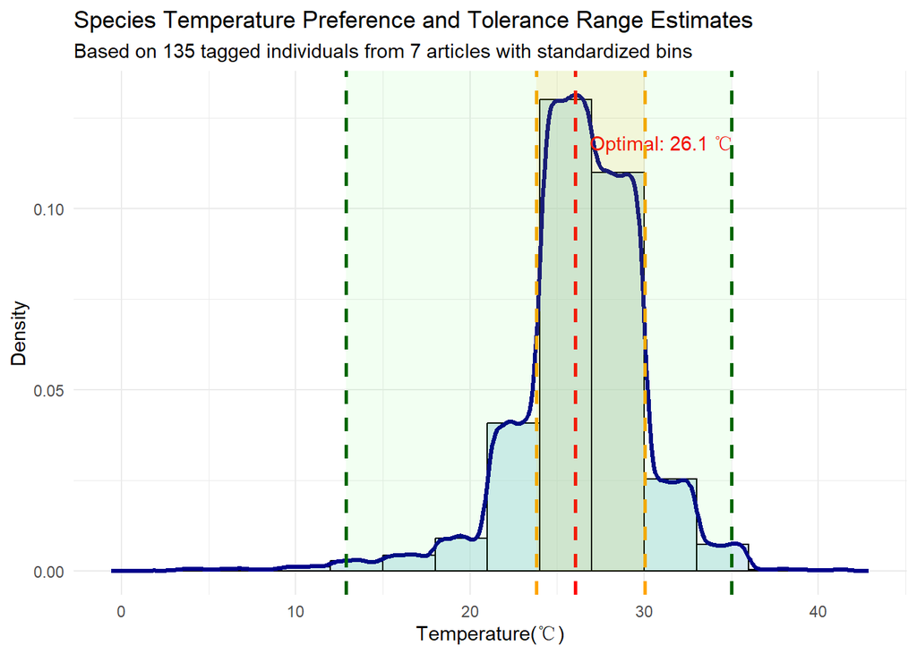